# 7 Secchi harmonization process

Following the completion of the {dataRetrieval} download process described previously, the pipeline contains raw WQP data for each parameter of interest. Before we harmonize each parameter we run through a series of universal “pre-harmonization” steps, which ensure that the datasets are appropriately formatted when entering their harmonization routines.

The text below first walks through the pre-harmonization steps for the raw Secchi disk depth dataset and then delves into the specifics of the harmonization process.

## 7.1 Pre-harmonization of the raw Secchi WQP dataset

At the start of the pre-harmonization process the raw Secchi disk depth WQP dataset contains 3.1 million rows.

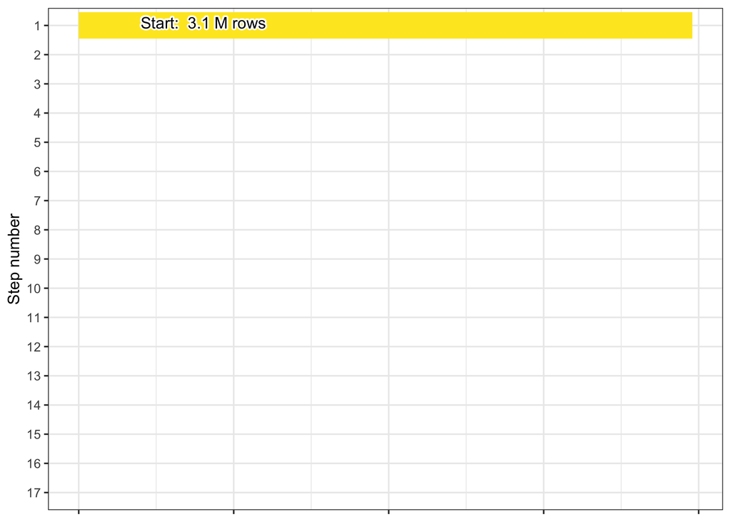

### 7.1.1 Missing results

Next, records that have missing data are dropped from the dataset. The row is flagged as missing if the result comment column contains any user-provided text indicating a missing value, currently including: `analysis lost`, `not analyzed`, `not recorded`, `not collected`, or `no measurement taken`.

0.7 thousand rows are dropped, resulting in a final count of 3.1 million.

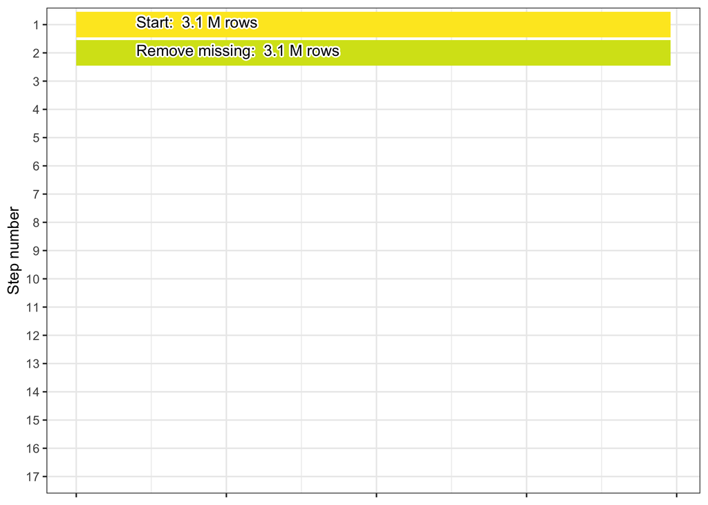

### 7.1.2 Filter Status

The final step in pre-harmonization is to filter the `ResultStatusIdentifier` column to include only the following statuses:

- `"Accepted"`
- `"Final"`
- `"Historical"`
- `"Validated"`
- `"Preliminary"`
- `NA`

These statuses generally indicate a reliable result having been reached, however we also include `NA` in an effort to be conservative. More specifically, when making decisions for this and other columns we occasionally retain `NA` values if removing the records would otherwise drop 10% or more of the available data.

This step removes 9.2 thousand rows of data, leaving it with 3.1 million rows remaining.

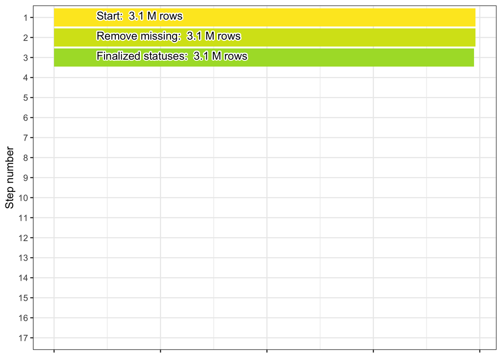

## 7.2 Harmonization-ready Secchi dataset

Once ready for harmonization, the Secchi-only dataset contains the following user-defined `characteristicNames`: Depth, Secchi disk depth, Depth, Secchi disk depth (choice list), Secchi Reading Condition (choice list), Secchi depth, Water transparency, Secchi disc.

These names are chosen in order to select for only those measurements that pertain to Secchi disk depth measurements.

### 7.2.1 Filter for water media

We next ensure that the media type for all SDD data is `"Surface Water"`, `"Water"`, `"Estuary"`, or `NA`. 2075 rows are removed. The final row count after this is 3.1 million.

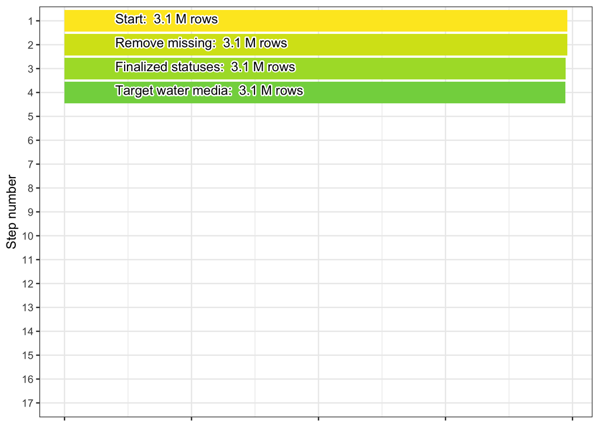

### 7.2.2 Document and remove fails

In this step we filter out records based on indications that they have failed data quality assurance or quality control for some reason given by the data provider (these instances are referred to here as “failures”).

Below are pie charts that break down the number of failure detections by column. Note that the plotting below is automated so if one or more of the columns listed above are not plotted, this indicates that the column(s) did not return any matches for the failure phrases. Also note that a single record can contain multiple failure phrases; therefore, failure phrases are not mutually exclusive.

#### 7.2.2.1 ResultCommentText fail detects

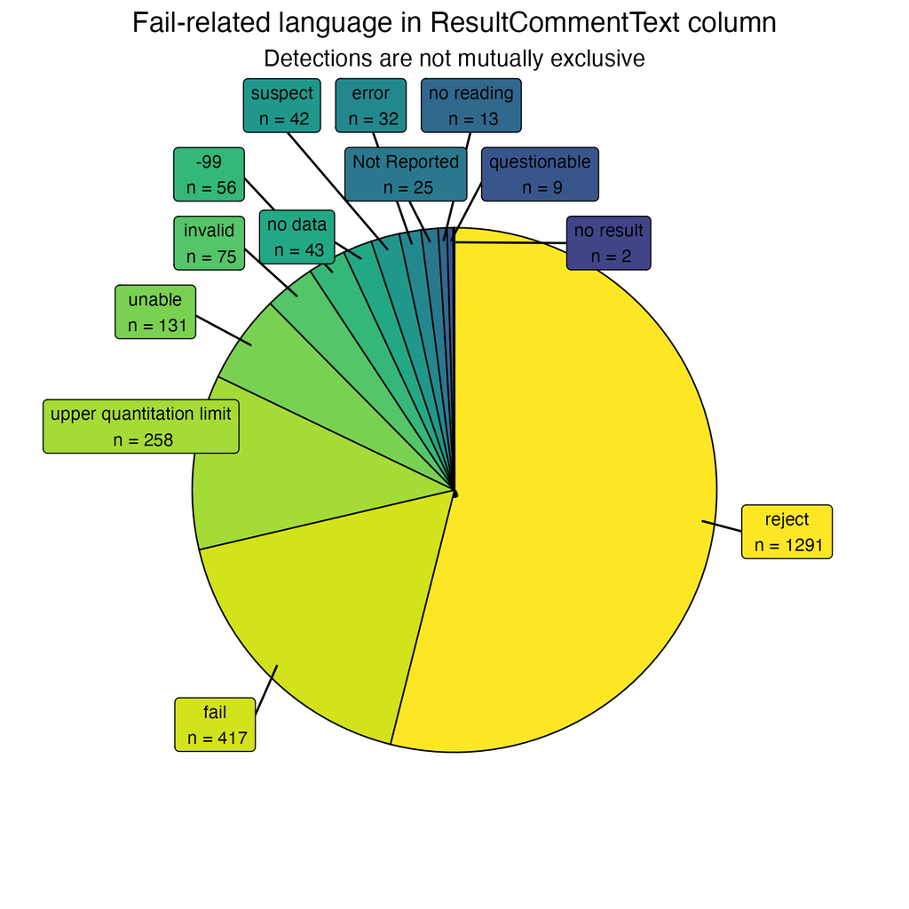

#### 7.2.2.2 ResultDetectionConditionText fail detects

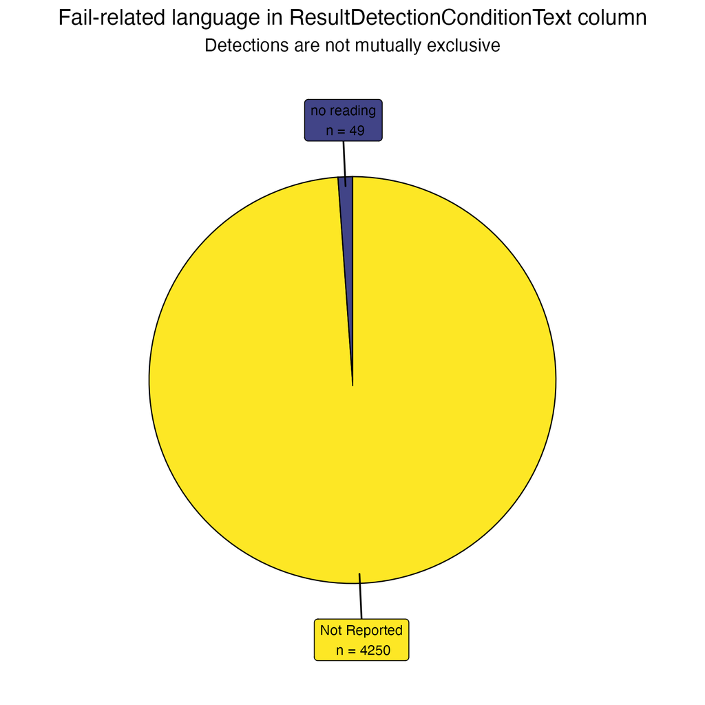

#### 7.2.2.3 ResultMeasureValue_original fail detects

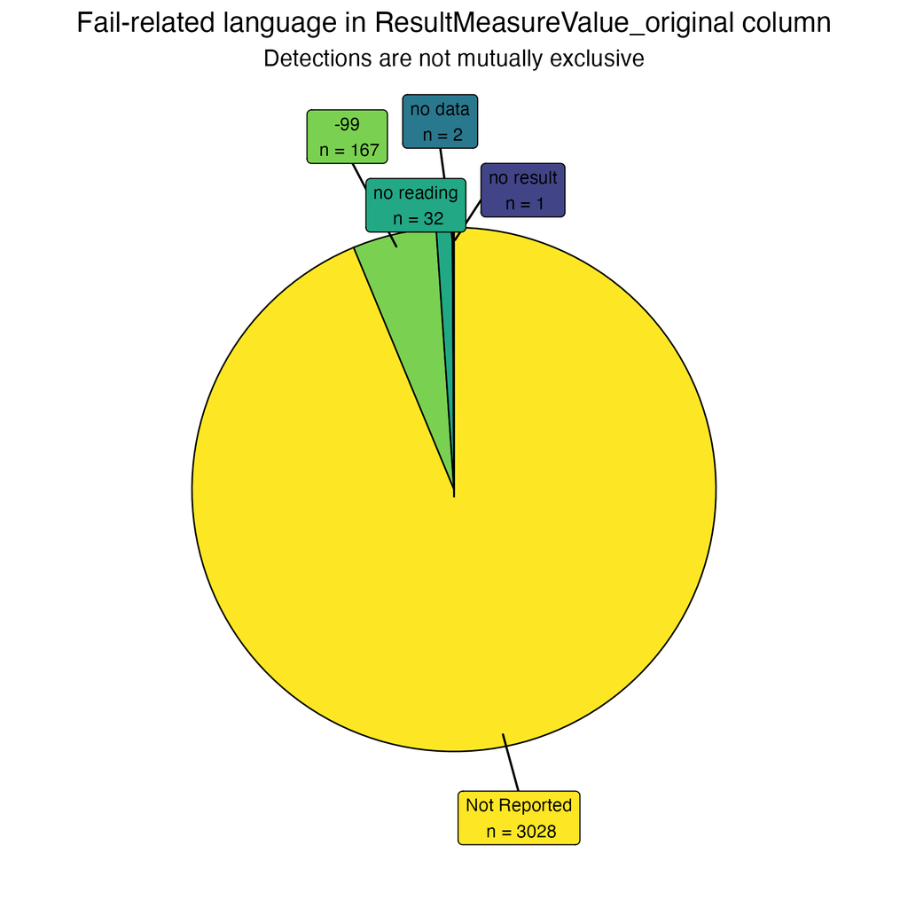

9.8 thousand rows are removed after detecting failure-related phrases and 3.1 million rows remain.

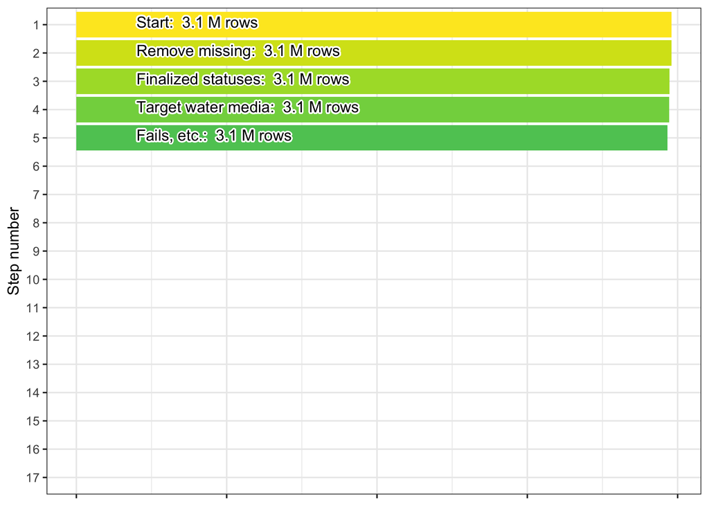

### 7.2.3 Clean special characters

We next address the issue of special characters in the Secchi disk depth measurements. Some entries in the dataset contain special characters at the beginning of the measurement value, which need to be removed for proper numerical analysis. We do this by first identifying measurements with the special characters `-`, `*`, or `=`. Then we remove those special characters and convert the values to numeric values and note which records were modified.

This should not result in a change in rows but we still check: 0 rows are removed and 3.1 million rows remain.

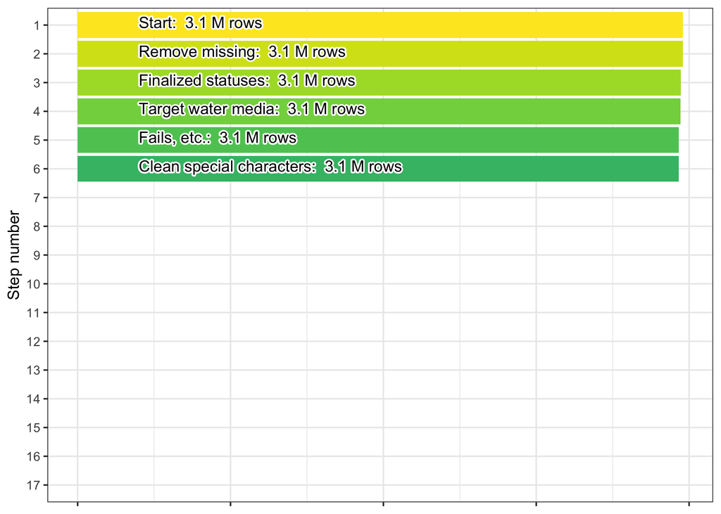

### 7.2.4 Clean values with “less than” data

In this step, we find and clean records containing `<` symbols. We first identify records where the numeric value is missing (`NA`) in the `ResultMeasureValue` column. We then look for the presence of a `<` symbol followed by a number in the `ResultMeasureValue_original` column. If these conditions are met and there are no alphabetical characters in the original value, we extract the numeric value after the `<` symbol. This extracted value is then used as the harmonized value for the measurement.

This step is one component of the rules defining our `mdl_flag` column, so it is labeled here as “Clean MDLs” (“MDL” = Method detection limit).

This should not result in a change in rows but we still check: 0 rows are removed and 3.1 million rows remain.

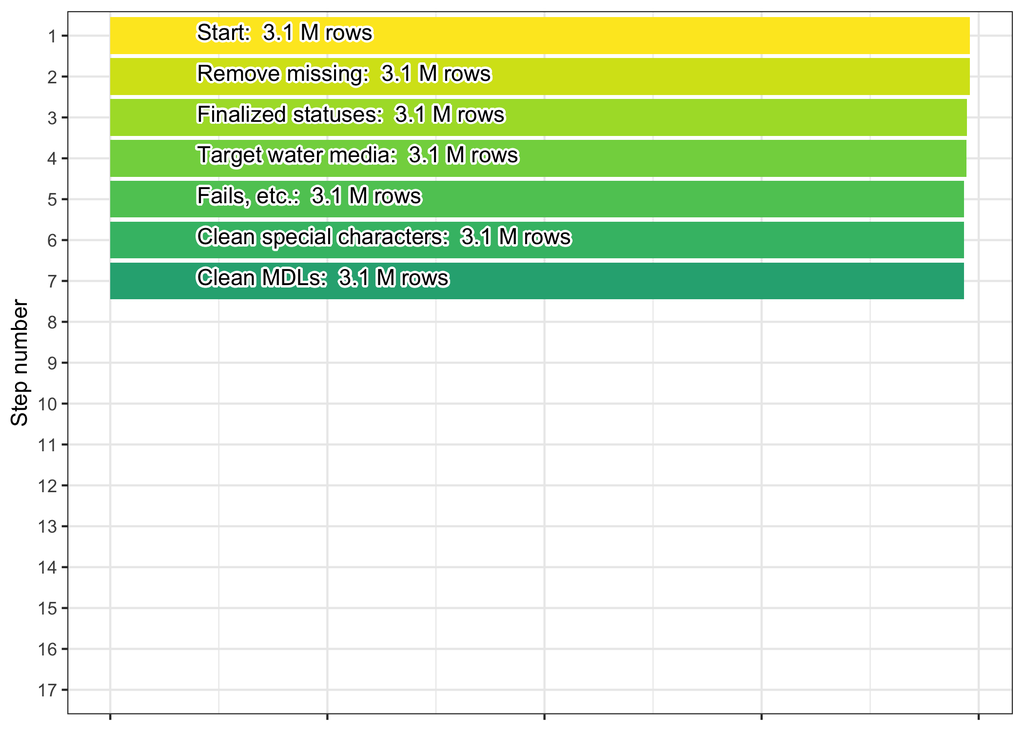

### 7.2.5 Clean values with “greater than” data

We next proceed to clean up values reported as “greater than” a certain measurement. This is similar to the proceeding step of cleaning up “less than” data.

1. Numeric-only version of the column was still `NA` after “<” removal
2. The original column text contained a number
3. The original column text contained a “>”
4. The original column text did not have any letters in it

We then used the numeric value (without “>”) as the record’s `harmonized_value` moving forward.

This should not result in a change in rows but we still check: 0 rows are removed and 3.1 million rows remain.

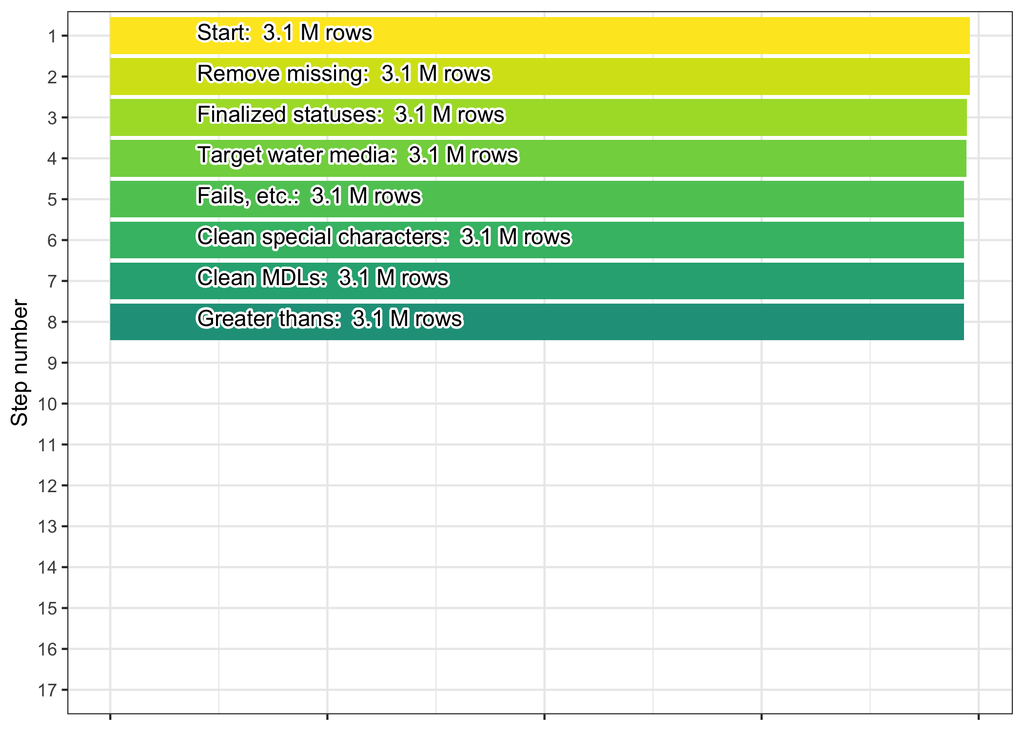

### 7.2.6 Gap filling harmonized values

After cleaning up the “greater than” values, we proceed to fill missing values in the `harmonized_value` column using Secchi disk depth information present in `ActivityBottomDepthHeightMeasure.MeasureValue`, `ActivityDepthHeightMeasure.MeasureValue`, and their corresponding units columns.

In order to gap-fill the harmonized_value column from the ActivityBottomDepthHeightMeasure we required both “bottom text” and no “negate text” to be present and for ActivityDepthHeightMeasure we required no “bottom text” present but instances of “negate text” was okay. “Bottom text” was defined as when the `ActivityCommentText`, `ResultCommentText`, and `ResultMeasureValue` columns contained language that referenced the “bottom” of the water body. Mentions of “bottom” alone were taken as a positive indicator that sampling hit the bottom, while the following other strings were used to negate such indication (“negate text”): “no bottom”, “not.*bottom”, ”couldn’t.*bottom”, “could not.*bottom”, ”unable to.*bottom”, “too deep”, “too shallow”, “doesn’t reach”, “did not reach”, “blocked”, “hidden”, “disappeared”, “hose frozen”, “pump frozen”, “cable not long enough”, “cord not long enough”, “won’t stay on bottom”, “current too strong”, “too windy”, “fast current”, “flooding”, “readings not on bottom”, “measurements not collected”, “sample taken at”, “depth too great”, “can’t get true bottom”, “seen on bottom: no”, “bottom reading not taken”, “afraid to touch bottom”, “forgot bottom reading”, “didn’t hit bottom”, “did not hit bottom”, “vegetation blocks”, “turbid”, “probe not on bottom”, “sonde.*not.*bottom”, “hydrolab not on bottom”, “profile not taken to bottom”, “unable to collect bottom”, “bottom.*not.*collected”, “bottom.*not.*recorded”. The strings listed here include the regex symbols of “.” for a single-character wildcard and “.*” for a greedy wildcard of any character length.

After this, we flagged these records with the `approx_flag`, indicating the source of the gap filled values:

- `0`: Value and units not adjusted (original `harmonized_value` is not `NA`)
- `1`: `harmonized_value` filled using `ActivityDepthHeightMeasure` column
- `2`: `harmonized_value` filled using `ActivityBottomDepthHeightMeasure` column

This should not result in a change in rows but we still check: 0 thousand rows are removed and 3.1 million rows remain.

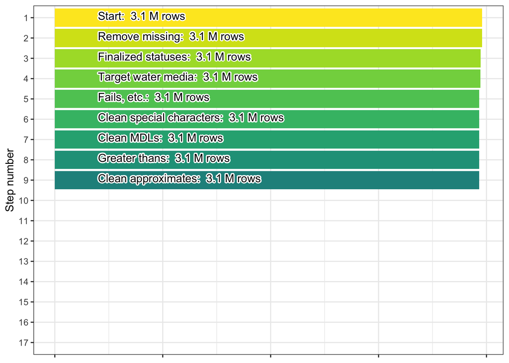

### 7.2.7 Drop unresolved NA measurements

The goal of the preceding three steps was to prevent records with seemingly missing measurement data from being dropped if there was still a chance of recovering a usable value. At this point we’ve finished with that process and we proceed to check for remaining records with `NA` values in their `harmonized_value` column. If they exist, they are dropped.

51.7 thousand rows are removed. The final row count after this is 3 million.

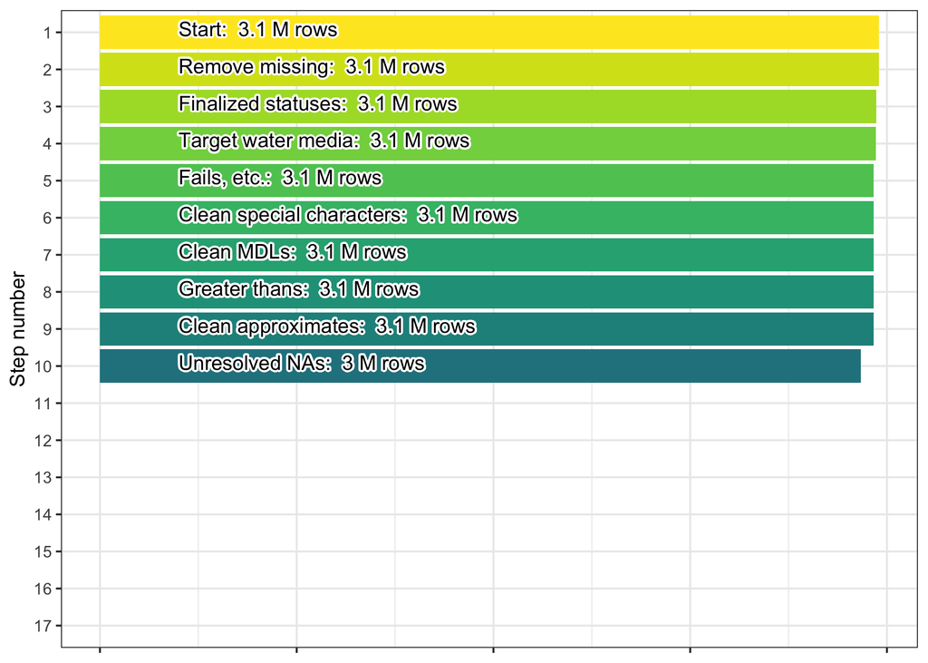

### 7.2.8 Harmonize record units

The next step in SDD harmonization is converting the units of WQP records. We create the following conversion table, which is used to translate units provided in WQP into meters (m):

| harmonized_units | conversion |
| --- | --- |
| m | 1.0000 |
| ft | 0.3048 |
| cm | 0.0100 |
| in | 0.0254 |
| mm | 0.0010 |
| feet | 0.3048 |
| meters | 1.0000 |
| mi | 1609.3400 |

Below is a pie chart that breaks down the different unit codes that were dropped in the unit harmonization process, and how many records were lost with each code.

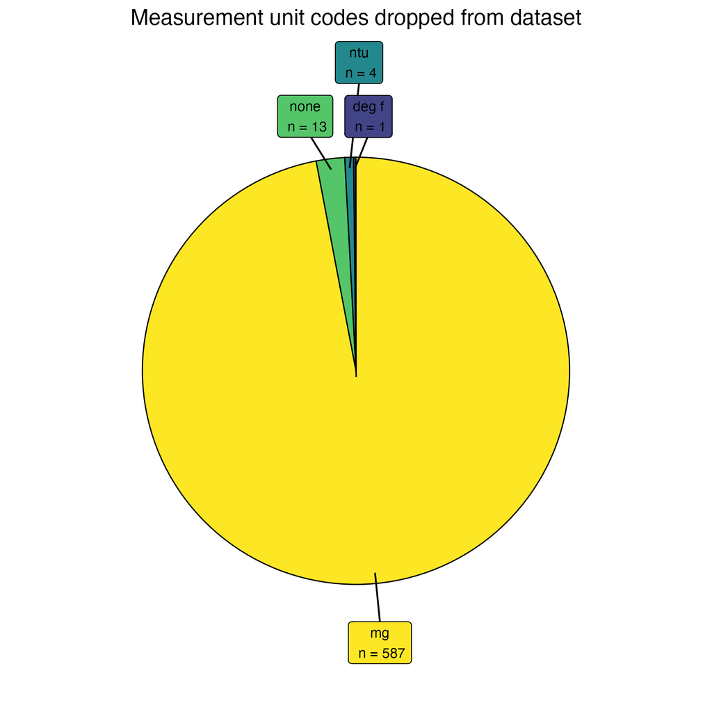

Additionally we provide a set of histograms of harmonized measurements by `CharacteristicName`:

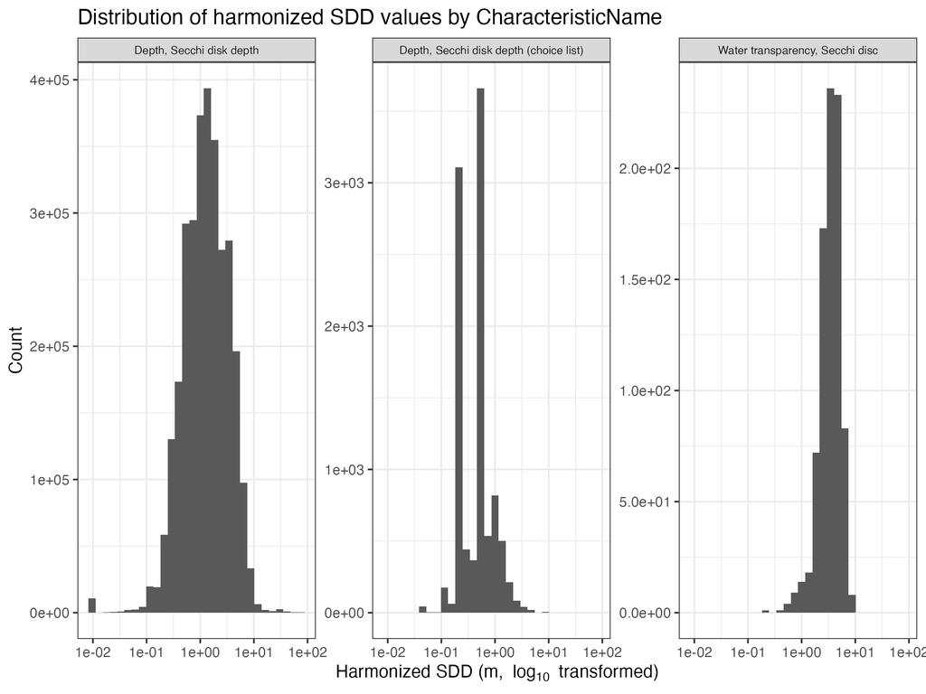

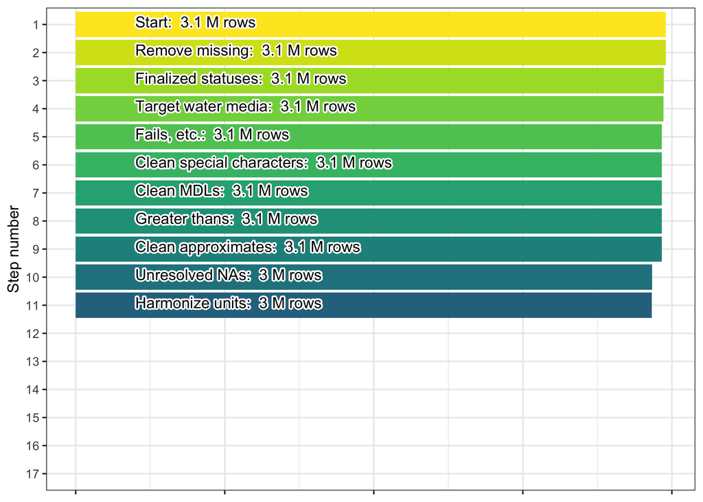

### 7.2.9 Clean and flag bottom depth data

The next harmonization step involved gap filling the `ActivityBottomDepthHeightMeasure.MeasureValue` and `ActivityBottomDepthHeightMeasure.MeasureUnitCode` columns.

There are four columns that explicitly contain depth information for a given WQP entry. Of these columns we are only interested in the `ActivityBottomDepthHeightMeasure.MeasureValue` column for Secchi disk depth because it may be an indicator of the bottom of the water body for a given WQP entry. Here we harmonize the values in the bottom depth column. To keep this data in line with the rest of the data in AquaSat v2, the other harmonized depth columns are filled with `NA` since Secchi disk depth is a discrete depth measurement. Those harmonized depth columns are:

- `harmonized_top_depth_value`
- `harmonized_top_depth_unit`
- `harmonized_discrete_depth_value`
- `harmonized_discrete_depth_unit`

In order to gap fill bottom depths we searched for records with previously identified bottom-related language and no information in the bottom depth value and unit columns. These entries were flagged using the `depth_flag` column, where `0` = bottom depth value not adjusted and no indication that Secchi disk hit bottom, and `1` = bottom depth value back filled with `harmonized_value` due to indication that Secchi disk hit bottom.

If an entry was flagged, then the `harmonized_bottom_depth_value` column was filled using the `harmonized_value` and the `harmonized_bottom_depth_unit` column was filled using the `harmonized_units` column. Finally, the units for the harmonized bottom depth values were converted to meters (m).

This should not result in a change in rows but we still check: 0 thousand rows are removed and 3 million rows remain.

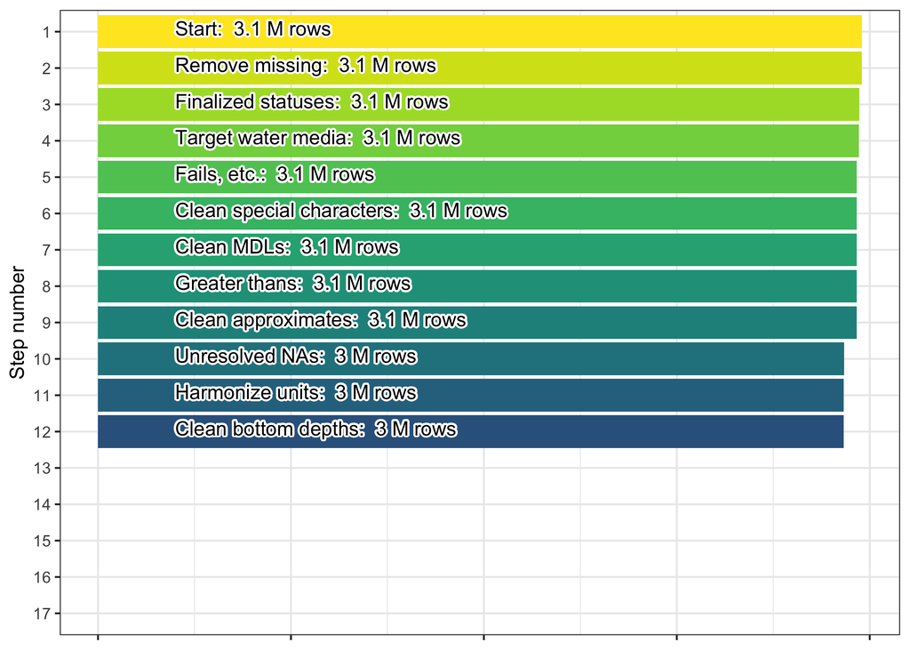

### 7.2.10 Filter methods

After cleaning and standardizing the Secchi bottom depth measurements, we proceed to filter the analytical methods used.

We check the `ResultAnalyticalMethod.MethodName` column for names that indicate non-Secchi disk depth measurements. Phrases used to flag and remove unrelated methods for Secchi disk depth data are: “analysis lost”, “not analyzed”, “not recorded”, “not collected”, “no measurement taken”.

This process drops 11.6 thousand rows leaving 3 million remaining.

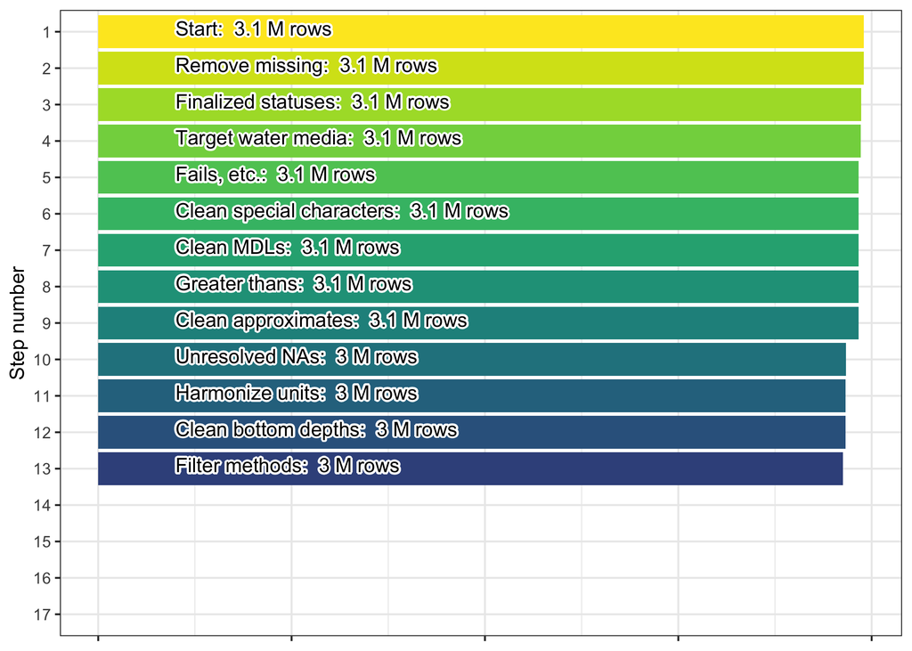

### 7.2.11 Tier methods

We then tiered the data using information on the time of day of the measurement, whether a viewscope was used, and whether the `harmonized_value` was gap filled.

Our tiers were informed by Davies-Colley et al. (1993). Specifically, 10am-2pm represents the ideal time range for measurements due to consistent lighting conditions and use of a viewscope can significantly improve measurement accuracy by reducing surface glare and wave effects. These considerations help assess the quality and reliability of the Secchi disk depth data across different measurement conditions.

We tiered the data as follows:

| **Tier** | **Name** | **Description** | **SDD details** |
| --- | --- | --- | --- |
| 0 | Restrictive | Data that are verifiably self-similar across organizations and time-periods and can be considered highly reliable and interoperable | Time was reported between 10am-2pm and was not 11:59:59. Method indicates use of viewscope |
| 1 | Narrowed | Data that we have good reason to believe are self-similar, but for which we can’t verify full interoperability across data providers | Either time reported was between 10am-2pm and was no 11:59:59, OR method indicates use of viewscope, but not both |
| 2 | Inclusive | Data that are assumed to be reliable and are harmonized to our best ability given the information available from the data provider. | Time not reported/was outside of 10am-2pm/was 11:59:59 and no indication that viewscope was used. Alternatively, any records with a harmonized_bottom_depth that is 0 or negative |
| 3 | Inclusive | Same as above | Data where the `harmonized_value` is gap filled from other columns in the record |

This should not result in a change in rows but we still check: 0 rows are removed and 3 million rows remain.

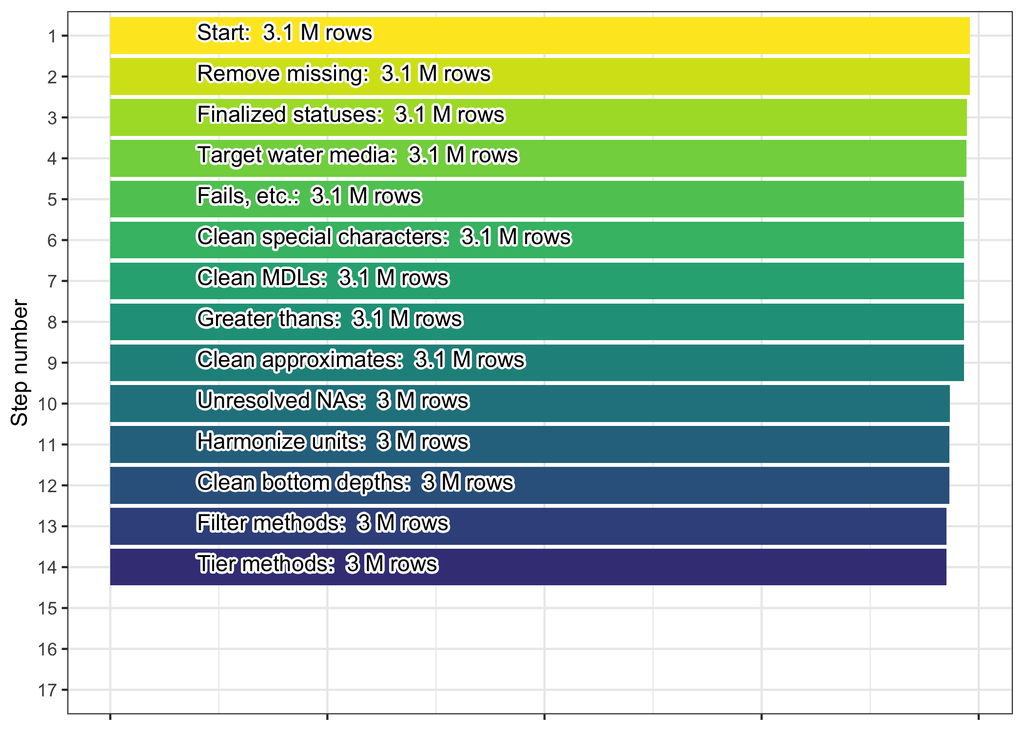

### 7.2.12 Flag

After cleaning and tiering the Secchi data, we conduct a final flagging sweep. This process creates several flags to provide additional context and quality indicators for each measurement.

This should not result in a change in rows but we still check: 0 rows are removed and 3 million rows remain.

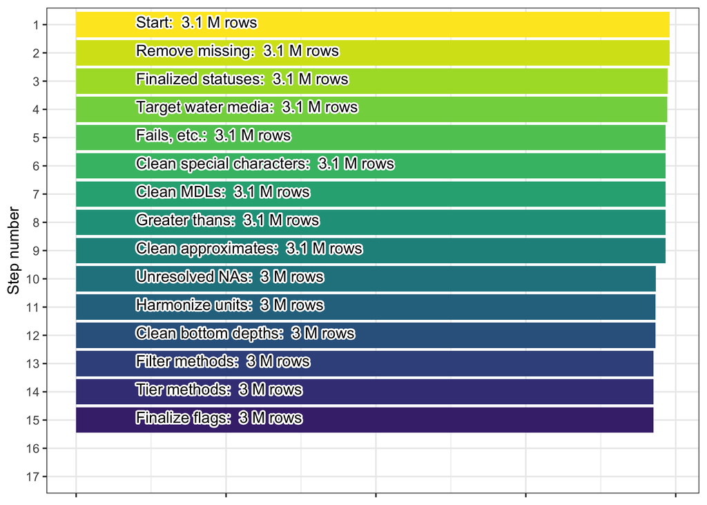

### 7.2.13 Remove unrealistic values

Before finalizing the dataset we removed Secchi disk depth values that were beyond a realistic threshold because they were likely erroneous. We used 80m as our cutoff for removal based on Gieskes et al. (1987).

Additionally, we convert values less than 0.01m to 0.01m based on observed Secchi disk depth records (NALMS, 2024).

These changes improve the overall reliability of the dataset by minimizing the amount of data with potential inaccuracies and preserving measurements that correctly describe the aquatic environment.

This process drops 1819 rows leaving 3 million remaining.

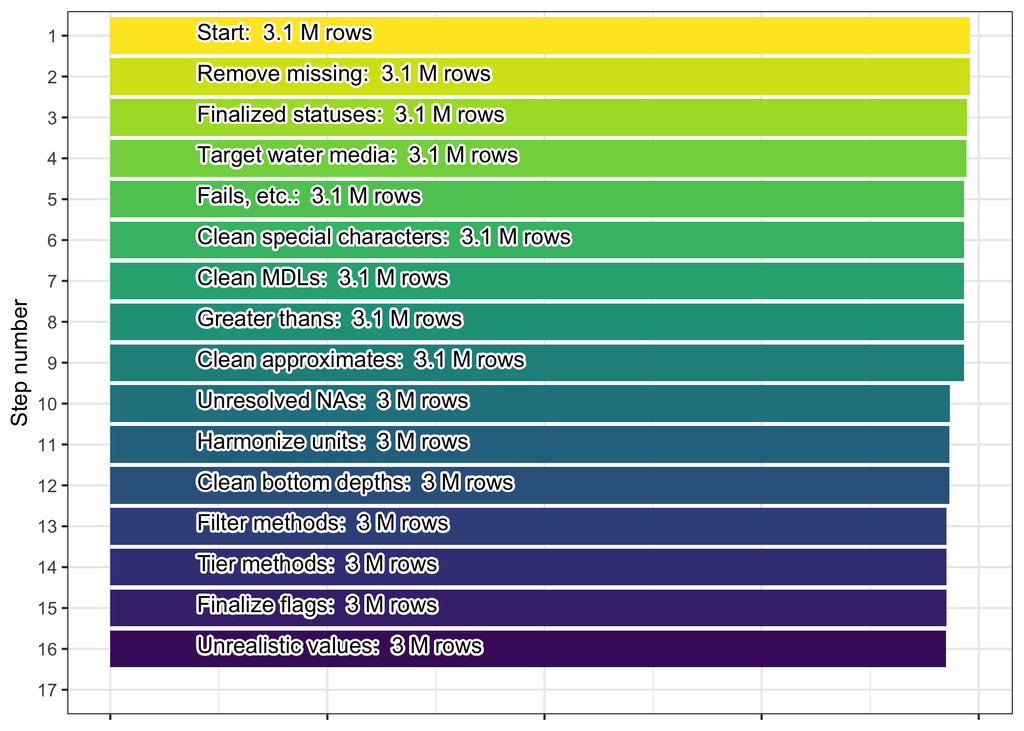

### 7.2.14 Aggregate simultaneous records

The final step of Secchi disk depth harmonization is to aggregate simultaneous observations. Any group of samples determined to be simultaneous are simplified into a single record containing the mean and coefficient of variation (CV) of the group. These can be either true duplicate entries in the Water Quality Portal (WQP) or records with non-identical values recorded at the same time and place and by the same organization (field and/or lab replicates/duplicates). The CV can be used to filter the dataset based on the amount of variability that is tolerable to specific use cases. Note, however, that many entries will have a CV that is `NA` because there are no duplicates or 0 because the records are duplicates and all entries have the same `harmonized_value`.

We identify simultaneous records to aggregate by creating identical subgroups (`subgroup_id`) from the following columns: `parameter`, `OrganizationIdentifier`, `MonitoringLocationIdentifier`, `MonitoringLocationTypeName`, `ResolvedMonitoringLocationTypeName`, `ActivityStartDate`, `ActivityStartTime.Time`, `ActivityStartTime.TimeZoneCode`, `harmonized_tz`, `harmonized_local_time`, `harmonized_utc`, `ActivityStartDateTime`, `harmonized_top_depth_value`, `harmonized_top_depth_unit`, `harmonized_bottom_depth_value`, `harmonized_bottom_depth_unit`, `harmonized_discrete_depth_value`, `harmonized_discrete_depth_unit`, `depth_flag`, `mdl_flag`, `approx_flag`, `greater_flag`, `tier`, `field_flag`, `misc_flag`, `harmonized_units`. This selection limits the columns included in the final dataset, but we also provide a copy of the dataset prior to its aggregation (pipeline target `p3_sdd_preagg_grouped`), and including the `subgroup_id` column, so that users can use the non-aggregated data as well and make joins between dataset versions.

The final, aggregated values are presented in the `harmonized_value` and `harmonized_value_cv` columns. The number of rows used per group is recorded in the `harmonized_row_count` column.

0.3 million rows dropped leaving 2.7 million remaining in the final harmonized and aggregated Secchi disk depth dataset.

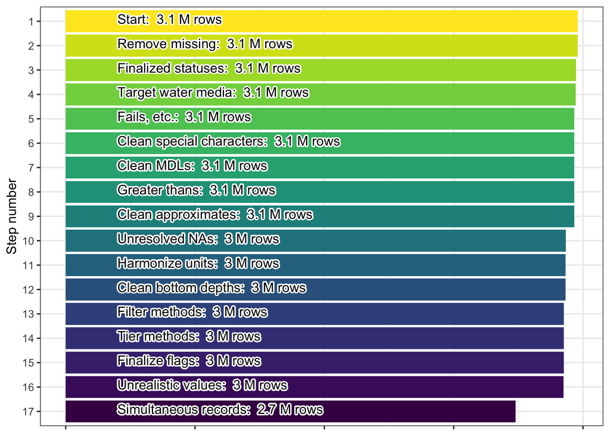

### 7.2.15 Harmonized Secchi disk depth

At this point the harmonization of the Secchi disk depth data from the WQP is complete and we export the final dataset for use later in the workflow.

Below are several sets of figures illustrating different qualities of the dataset:

1. Histograms showing the distribution of harmonized measurements (top) and CVs (bottom) broken down by `tier` *after* aggregating simultaneous records.

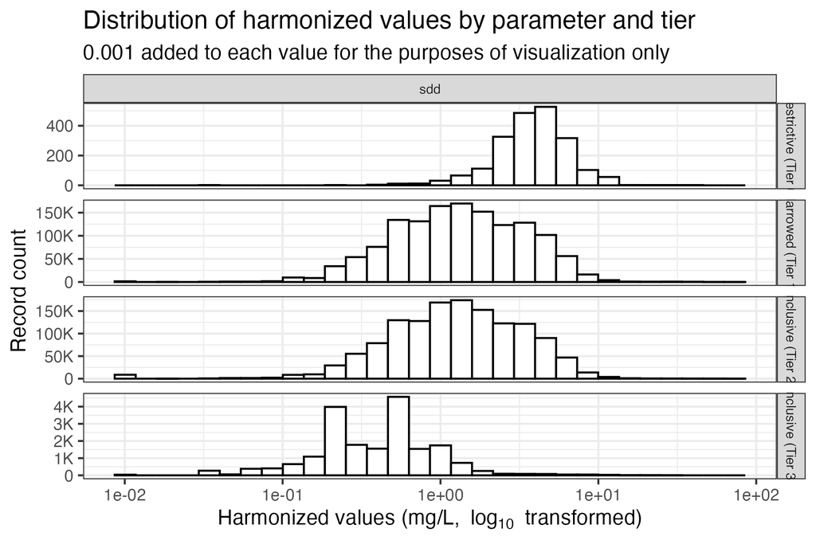

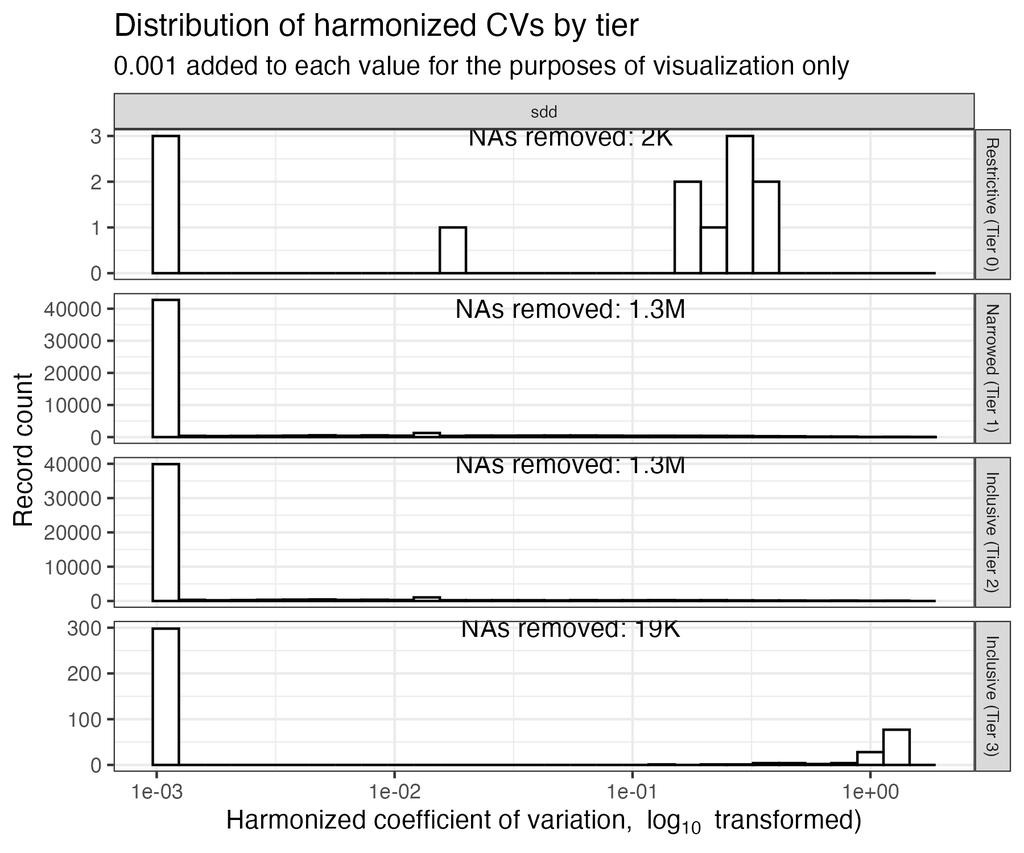

2. Maps showing the geographic distribution of records by tier within the US:

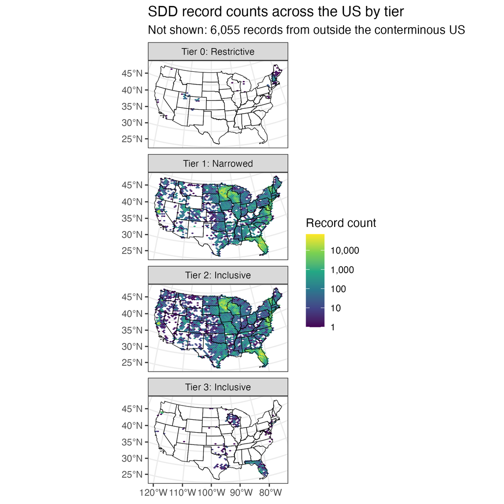

3. Lastly, bar charts showing the distribution of values by tier across years, months, and days of the week:

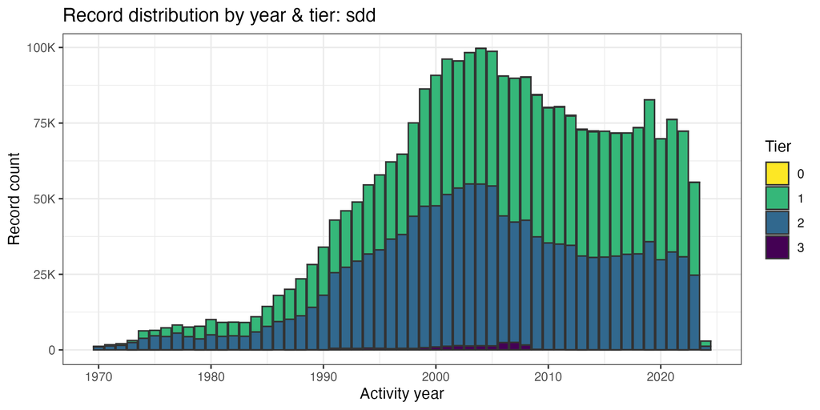

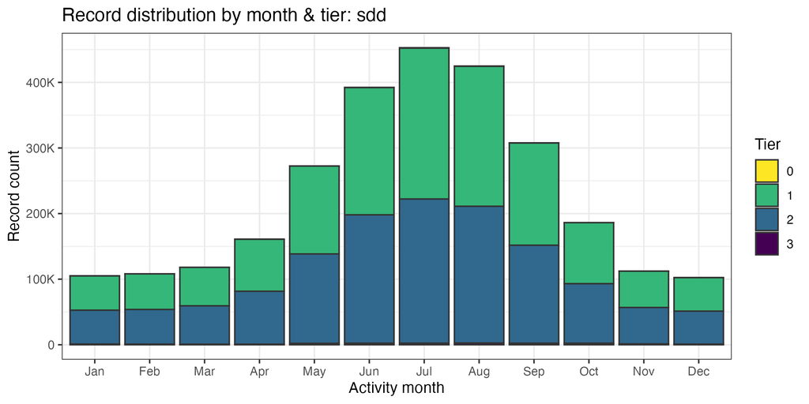

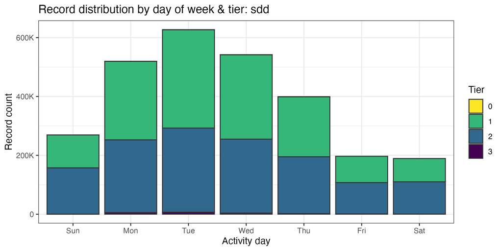